# Statistical Case Studies, Project 1 Part 1, Code

Anna Scollay, Lewis Seath, Zacharias Onyejiaka

2026-10-12

## Data import, parsing & cleaning

We start by loading the required libraries.

```r
# Load required libraries
library(tidyverse)
library(knitr)
library(kableExtra)
library(ismev)
```

Next, we fetch data from our chosen river gauging station, *Don at Parkhill* in Scotland. For 10 years of 15-minute interval data, we are fetching over 350,000 records. To minimise the chances of a 504 Gateway Timeout, we will fetch the data in 1-year blocks and save it to our local disk so future runs do not have to re-download the data.

```r
# Extend R's default HTTP timeout limit to 300 seconds
options(timeout = 300)

cache_file <- "river_don_parkhill_flow.rds"

if (file.exists(cache_file)) {
  # Load from local cache if file already exists
  river_data <- readRDS(cache_file)

} else {
  # If no local cache exists, fetch from SEPA in 1-year chunks
  start_years <- seq(2016, 2025, by = 1)

  fetch_chunk <- function(yr) {
    from_date <- paste0(yr, "-08-31T00:00:00")
    to_date   <- paste0(yr + 1, "-08-31T00:00:00")

    url <- paste0(
      "https://timeseries.sepa.org.uk/KiWIS/KiWIS?",
      "service=kisters&type=queryServices&datasource=0&",
      "request=getTimeseriesValues&ts_path=1/234292/Q/15m.Cmd&",
      "from=", from_date, "&to=", to_date, "&",
      "metadata=true&returnfields=Timestamp,Value,Quality%20Code&format=csv"
    )

    read_delim(
      url,
      delim = ";",
      comment = "#",
      col_names = c("Timestamp", "Discharge", "QualityCode"),
      show_col_types = FALSE
    )
  }

  river_data <- map_dfr(start_years, fetch_chunk) %>%
    mutate(Timestamp = as.POSIXct(Timestamp, format = "%Y-%m-%dT%H:%M:%S")) %>%
    filter(!is.na(Discharge)) %>%
    distinct(Timestamp, .keep_all = TRUE)

  # Save to local file so future runs don't need to use the API
  saveRDS(river_data, cache_file)
}
```

Shifting our attention to the `QualityCode` column, let us assess the data segmented by quality code.

Table 1 — quality codes

| Code number | Code name | Abbreviated code name |
| --- | --- | --- |
| 50 | Good | G |
| 100 | Estimated | E |
| 140 | Provisional | Prov |
| 150 | Suspect | S |
| 200 | Unchecked (imported from legacy database) | V |
| 254 | Unchecked | U |

```r
# Segment data by QualityCode split
quality_summary <- river_data %>%
  count(QualityCode) %>%
  mutate(
    Percentage = sprintf("%.2f%%", (n / sum(n)) * 100)
  )

print(quality_summary)
```

```
## # A tibble: 3 × 3
##   QualityCode      n Percentage
##         <dbl>  <int> <chr>
## 1          50 336175 95.89%
## 2         100  14388 4.10%
## 3         254     30 0.01%
```

We observe that 95.89% of our data is “Good” by SEPA’s quality control standards.

## Discharge summary statistics

Below is the statistical summary of the 15-minute flow discharge ($m^3/s$) for the River Don at Parkhill across the 10-year period:

```r
summary(river_data$Discharge)
```

```
##    Min. 1st Qu.  Median    Mean 3rd Qu.    Max.
##   3.903   8.790  14.714  21.669  25.440 418.679
```

## River Hydrograph

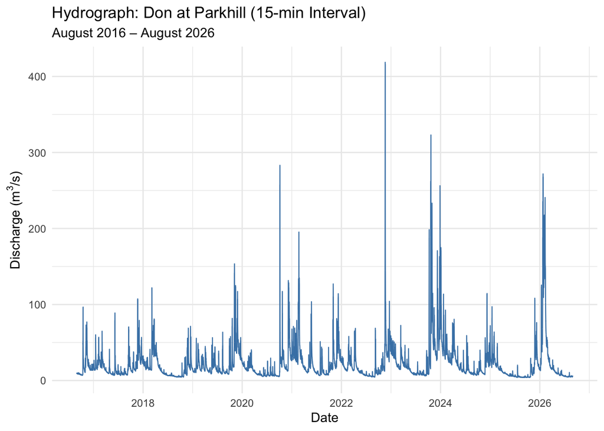

```r
ggplot(river_data, aes(x = Timestamp, y = Discharge)) +
  geom_line(color = "steelblue", linewidth = 0.4) +
  labs(
    title = "Hydrograph: Don at Parkhill (15-min Interval)",
    subtitle = "August 2016 – August 2026",
    x = "Date",
    y = expression("Discharge ("*m^3*"/s)")
  ) +
  theme_minimal()
```

# Exploratory Analysis

## Time variables

We add three time variables used throughout this section: the month, the season, and the water year. A water year runs from September to August and is labelled by the year it ends in, which keeps each winter’s high flows together in the same year.

```r
river_data <- river_data %>%
  mutate(
    month      = month(Timestamp, label = TRUE),
    water_year = if_else(month(Timestamp) >= 9, year(Timestamp) + 1, year(Timestamp)),
    season     = case_when(
      month(Timestamp) %in% c(12, 1, 2) ~ "Winter",
      month(Timestamp) %in% c(3, 4, 5)  ~ "Spring",
      month(Timestamp) %in% c(6, 7, 8)  ~ "Summer",
      TRUE                              ~ "Autumn"
    ),
    season = factor(season, levels = c("Winter", "Spring", "Summer", "Autumn"))
  )
```

## Long-term pattern

Adding the monthly mean and the overall mean to the hydrograph shows the contrast between the typical flow, which moves smoothly with the seasons, and the short peaks that rise far above it.

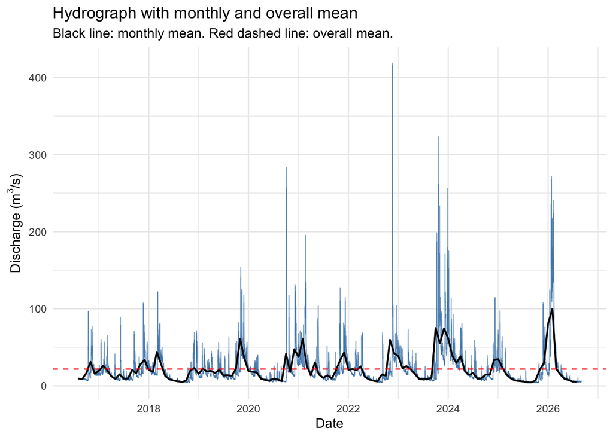

```r
monthly_mean <- river_data %>%
  group_by(month_start = floor_date(Timestamp, "month")) %>%
  summarise(Discharge = mean(Discharge))

ggplot(river_data, aes(x = Timestamp, y = Discharge)) +
  geom_line(color = "steelblue", linewidth = 0.4, alpha = 0.6) +
  geom_line(data = monthly_mean, aes(x = month_start), color = "black", linewidth = 0.7) +
  geom_hline(yintercept = mean(river_data$Discharge), linetype = "dashed", color = "red") +
  labs(
    title = "Hydrograph with monthly and overall mean",
    subtitle = "Black line: monthly mean. Red dashed line: overall mean.",
    x = "Date",
    y = expression("Discharge ("*m^3*"/s)")
  ) +
  theme_minimal()
```

## Distribution of flow

```r
river_data %>%
  summarise(
    `Mean`               = mean(Discharge),
    `Standard deviation` = sd(Discharge),
    `Minimum`            = min(Discharge),
    `25th percentile`    = quantile(Discharge, 0.25),
    `Median`             = median(Discharge),
    `75th percentile`    = quantile(Discharge, 0.75),
    `95th percentile`    = quantile(Discharge, 0.95),
    `99th percentile`    = quantile(Discharge, 0.99),
    `Maximum`            = max(Discharge)
  ) %>%
  pivot_longer(everything(), names_to = "Statistic", values_to = "Value") %>%
  kable(format = "html", digits = 2, caption = "Summary statistics for 15-minute discharge (m³/s)") %>%
  kable_styling(
    bootstrap_options = c("bordered", "striped", "hover"),
    full_width = FALSE,
    position = "left"
  )
```

Summary statistics for 15-minute discharge (m³/s)

| Statistic | Value |
| --- | --- |
| Mean | 21.67 |
| Standard deviation | 24.37 |
| Minimum | 3.90 |
| 25th percentile | 8.79 |
| Median | 14.71 |
| 75th percentile | 25.44 |
| 95th percentile | 57.88 |
| 99th percentile | 130.96 |
| Maximum | 418.68 |

Flow is strongly right-skewed: most of the time the river is low, with occasional very high peaks. A log scale makes the shape easier to see.

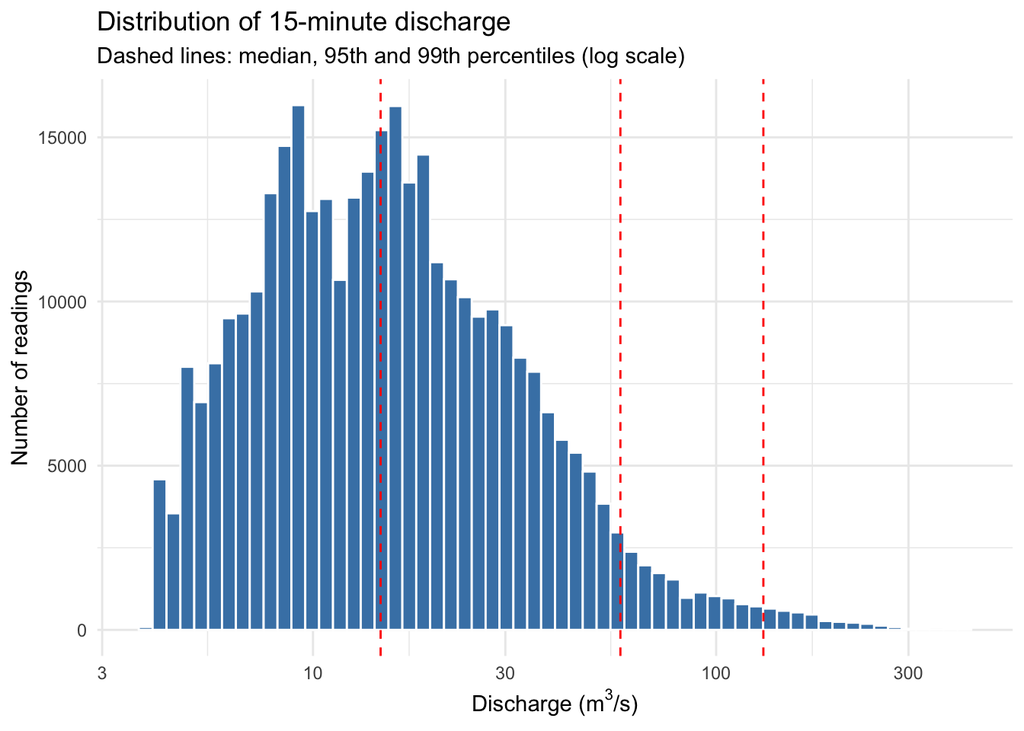

```r
ggplot(river_data, aes(x = Discharge)) +
  geom_histogram(bins = 60, fill = "steelblue", colour = "white") +
  geom_vline(xintercept = quantile(river_data$Discharge, c(0.5, 0.95, 0.99)),
             linetype = "dashed", colour = "red") +
  scale_x_log10() +
  labs(
    title = "Distribution of 15-minute discharge",
    subtitle = "Dashed lines: median, 95th and 99th percentiles (log scale)",
    x = expression("Discharge ("*m^3*"/s)"),
    y = "Number of readings"
  ) +
  theme_minimal()
```

## Seasonal pattern

```r
river_data %>%
  group_by(month) %>%
  summarise(
    Mean   = mean(Discharge),
    Median = median(Discharge),
    `95th percentile` = quantile(Discharge, 0.95),
    Maximum = max(Discharge)
  ) %>%
  rename(Month = month) %>%
  kable(format = "html", digits = 2, caption = "Discharge by month (m³/s)") %>%
  kable_styling(
    bootstrap_options = c("bordered", "striped", "hover"),
    full_width = FALSE,
    position = "left"
  )
```

Discharge by month (m³/s)

| Month | Mean | Median | 95th percentile | Maximum |
| --- | --- | --- | --- | --- |
| Jan | 34.78 | 24.78 | 97.58 | 271.84 |
| Feb | 35.09 | 23.90 | 122.03 | 240.84 |
| Mar | 23.95 | 20.55 | 44.76 | 121.98 |
| Apr | 19.20 | 15.31 | 41.15 | 80.63 |
| May | 13.86 | 11.14 | 29.56 | 103.72 |
| Jun | 10.96 | 8.85 | 22.97 | 88.89 |
| Jul | 9.28 | 7.75 | 18.49 | 59.17 |
| Aug | 8.43 | 7.79 | 14.83 | 63.62 |
| Sep | 10.12 | 7.91 | 25.34 | 70.53 |
| Oct | 23.22 | 14.49 | 77.46 | 323.07 |
| Nov | 34.11 | 22.40 | 87.85 | 418.68 |
| Dec | 37.84 | 30.60 | 90.53 | 256.33 |

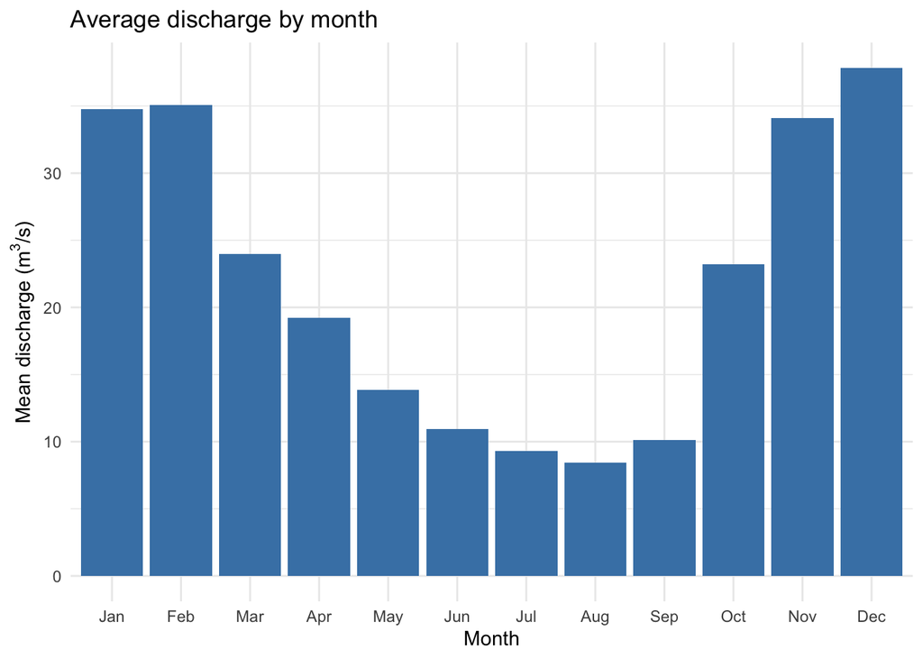

```r
ggplot(river_data, aes(x = month, y = Discharge)) +
  stat_summary(fun = mean, geom = "col", fill = "steelblue") +
  labs(
    title = "Average discharge by month",
    x = "Month",
    y = expression("Mean discharge ("*m^3*"/s)")
  ) +
  theme_minimal()
```

To focus on the extremes rather than typical flows, we also count how many days in total the river spent above its 95th percentile of flow in each month (each day has 96 readings).

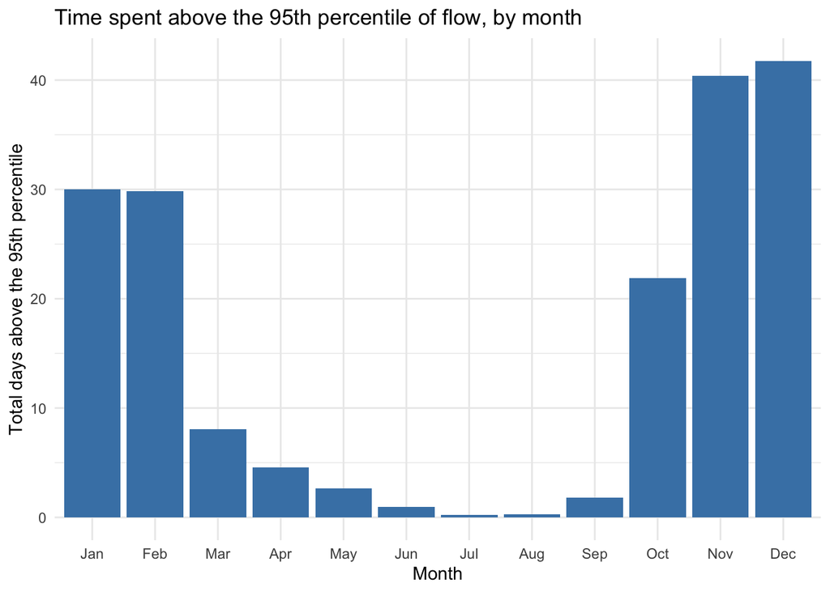

```r
high_flow <- quantile(river_data$Discharge, 0.95)

river_data %>%
  filter(Discharge > high_flow) %>%
  count(month) %>%
  ggplot(aes(x = month, y = n / 96)) +
  geom_col(fill = "steelblue") +
  labs(
    title = "Time spent above the 95th percentile of flow, by month",
    x = "Month",
    y = "Total days above the 95th percentile"
  ) +
  theme_minimal()
```

Grouping by season shows the spread of flows as well as the typical level.

```r
river_data %>%
  group_by(season) %>%
  summarise(
    Mean   = mean(Discharge),
    Median = median(Discharge),
    `95th percentile` = quantile(Discharge, 0.95),
    Maximum = max(Discharge)
  ) %>%
  rename(Season = season) %>%
  kable(format = "html", digits = 2, caption = "Discharge by season (m³/s)") %>%
  kable_styling(
    bootstrap_options = c("bordered", "striped", "hover"),
    full_width = FALSE,
    position = "left"
  )
```

Discharge by season (m³/s)

| Season | Mean | Median | 95th percentile | Maximum |
| --- | --- | --- | --- | --- |
| Winter | 35.93 | 26.95 | 98.58 | 271.84 |
| Spring | 19.00 | 15.56 | 40.43 | 121.98 |
| Summer | 9.54 | 8.16 | 20.08 | 88.89 |
| Autumn | 22.49 | 13.42 | 69.48 | 418.68 |

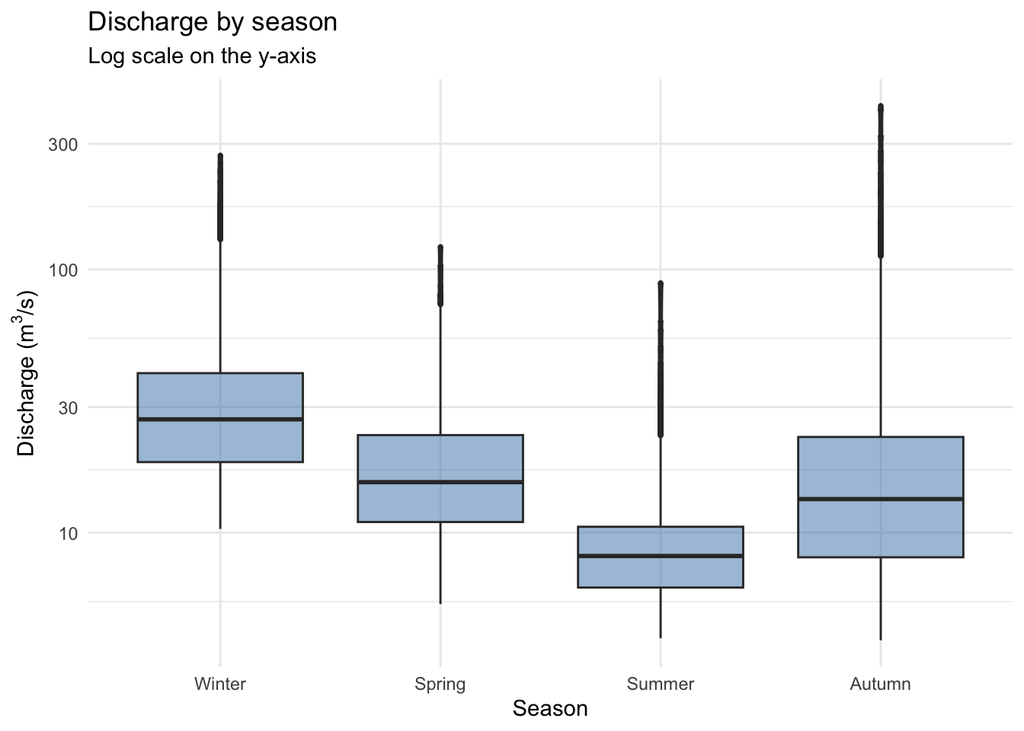

```r
ggplot(river_data, aes(x = season, y = Discharge)) +
  geom_boxplot(fill = "steelblue", alpha = 0.5, outlier.size = 0.5) +
  scale_y_log10() +
  labs(
    title = "Discharge by season",
    subtitle = "Log scale on the y-axis",
    x = "Season",
    y = expression("Discharge ("*m^3*"/s)")
  ) +
  theme_minimal()
```

## Year-to-year variation

The largest flow in each water year shows how much the most extreme events vary from one year to the next.

```r
river_data %>%
  group_by(water_year) %>%
  summarise(
    Mean    = mean(Discharge),
    Median  = median(Discharge),
    Maximum = max(Discharge),
    `Date of maximum` = format(Timestamp[which.max(Discharge)], "%d %b %Y")
  ) %>%
  rename(`Water year` = water_year) %>%
  kable(format = "html", digits = 2, caption = "Discharge by water year (m³/s)") %>%
  kable_styling(
    bootstrap_options = c("bordered", "striped", "hover"),
    full_width = FALSE,
    position = "left"
  )
```

Discharge by water year (m³/s)

| Water year | Mean | Median | Maximum | Date of maximum |
| --- | --- | --- | --- | --- |
| 2016 | 9.54 | 9.61 | 9.74 | 31 Aug 2016 |
| 2017 | 16.01 | 13.37 | 96.65 | 16 Oct 2016 |
| 2018 | 20.24 | 15.98 | 121.98 | 07 Mar 2018 |
| 2019 | 16.18 | 13.52 | 71.30 | 16 Dec 2018 |
| 2020 | 18.86 | 13.12 | 153.53 | 05 Nov 2019 |
| 2021 | 26.48 | 18.66 | 283.14 | 05 Oct 2020 |
| 2022 | 18.75 | 14.59 | 127.10 | 01 Nov 2021 |
| 2023 | 23.39 | 16.77 | 418.68 | 19 Nov 2022 |
| 2024 | 36.86 | 26.59 | 323.07 | 22 Oct 2023 |
| 2025 | 14.83 | 9.97 | 114.55 | 08 Dec 2024 |
| 2026 | 25.09 | 10.20 | 271.84 | 25 Jan 2026 |

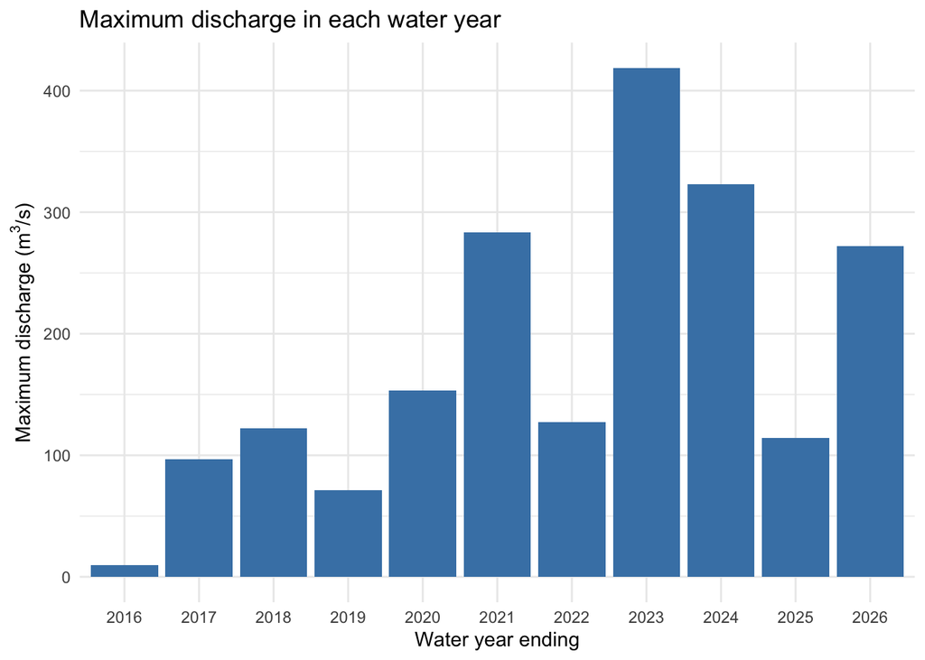

```r
river_data %>%
  group_by(water_year) %>%
  summarise(Maximum = max(Discharge)) %>%
  ggplot(aes(x = factor(water_year), y = Maximum)) +
  geom_col(fill = "steelblue") +
  labs(
    title = "Maximum discharge in each water year",
    x = "Water year ending",
    y = expression("Maximum discharge ("*m^3*"/s)")
  ) +
  theme_minimal()
```

## Shape of an individual event

Zooming in on the 30 days either side of the largest recorded flow shows the shape of individual hydrograph peaks: a fast rise followed by a slower fall.

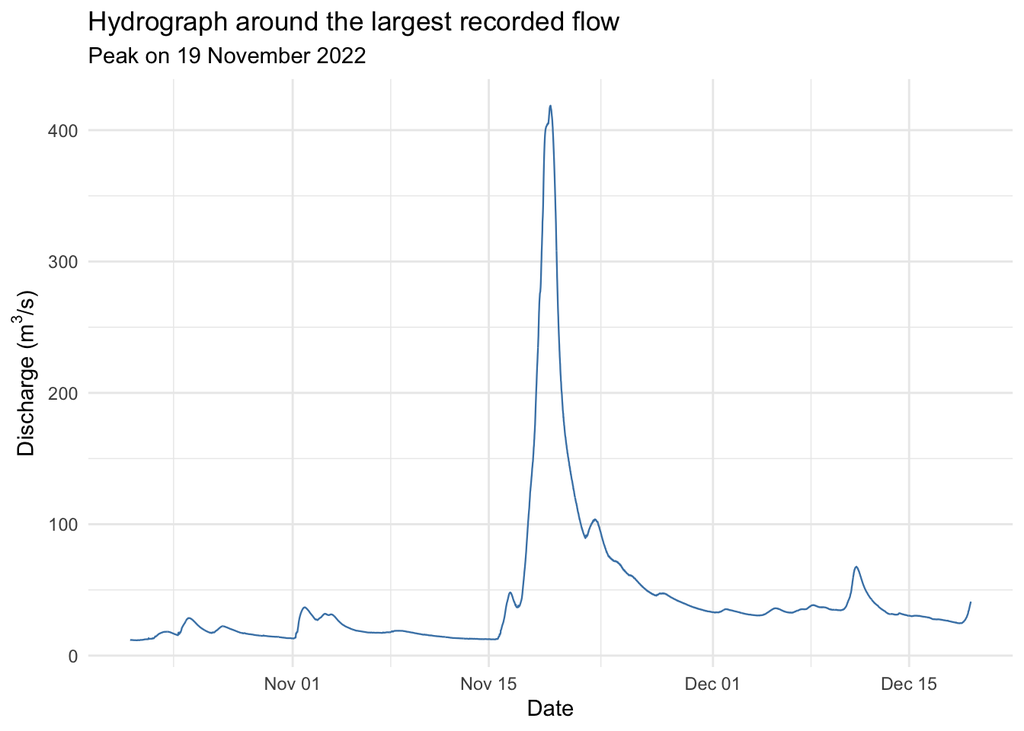

```r
biggest <- river_data$Timestamp[which.max(river_data$Discharge)]

river_data %>%
  filter(Timestamp >= biggest - 30 * 24 * 3600,
         Timestamp <= biggest + 30 * 24 * 3600) %>%
  ggplot(aes(x = Timestamp, y = Discharge)) +
  geom_line(color = "steelblue", linewidth = 0.4) +
  labs(
    title = "Hydrograph around the largest recorded flow",
    subtitle = paste("Peak on", format(biggest, "%d %B %Y")),
    x = "Date",
    y = expression("Discharge ("*m^3*"/s)")
  ) +
  theme_minimal()
```

# Threshold

## 3-5 per year method

```r
# Thresholds to try: 0, 1, 2, ... up to the maximum flow
thresholds <- 0:max(river_data$Discharge)

# Peaks per year for each threshold
peaks_per_year <- sapply(thresholds, function(u) {
  above <- river_data$Discharge > u
  sum(above & !lag(above, default = FALSE))
}) / n_distinct(river_data$water_year)

# Thresholds giving 3 to 5 peaks per year
thresholds[peaks_per_year >= 3 & peaks_per_year <= 5]
```

```
##  [1]  73  75  76  77  78  80  81  82  83  84  85  86  87  88  89  90  91  92  93
## [20]  94  95  96  97  98  99 100 101 102 103 105 106 107 110 113
```

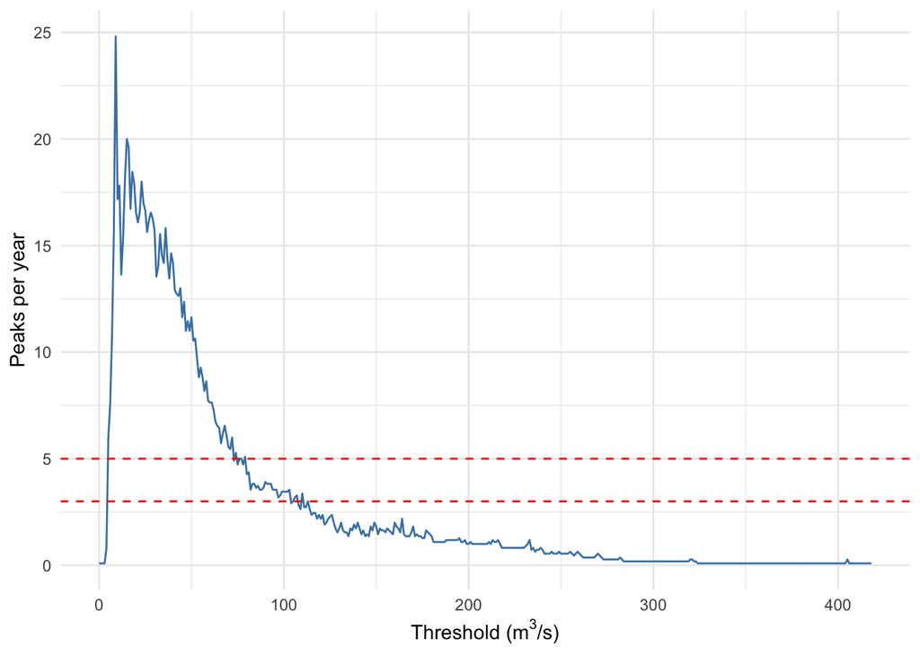

```r
# Plot
ggplot(tibble(thresholds, peaks_per_year), aes(x = thresholds, y = peaks_per_year)) +
  geom_line(color = "steelblue") +
  geom_hline(yintercept = c(3, 5), linetype = "dashed", color = "red") +
  labs(x = expression("Threshold ("*m^3*"/s)"), y = "Peaks per year") +
  theme_minimal()
```

## Percentile method

```r
# Threshold: the 95th percentile of flow
u95 <- quantile(river_data$Discharge, 0.95)
u95
```

```
##    95%
## 57.878
```

```r
# Peaks: the highest reading in each separate period above the threshold
peaks_95 <- river_data %>%
  mutate(above = Discharge > u95,
         start = above & !lag(above, default = FALSE),   # TRUE when the flow first goes above the threshold
         run   = cumsum(start)) %>%                       # numbers each period above the threshold
  filter(above) %>%
  group_by(run) %>%
  slice_max(Discharge, n = 1, with_ties = FALSE) %>%
  ungroup()

# Number of peaks, and average peaks per year
nrow(peaks_95)
```

```
## [1] 94
```

```r
nrow(peaks_95) / n_distinct(river_data$water_year)
```

```
## [1] 8.545455
```

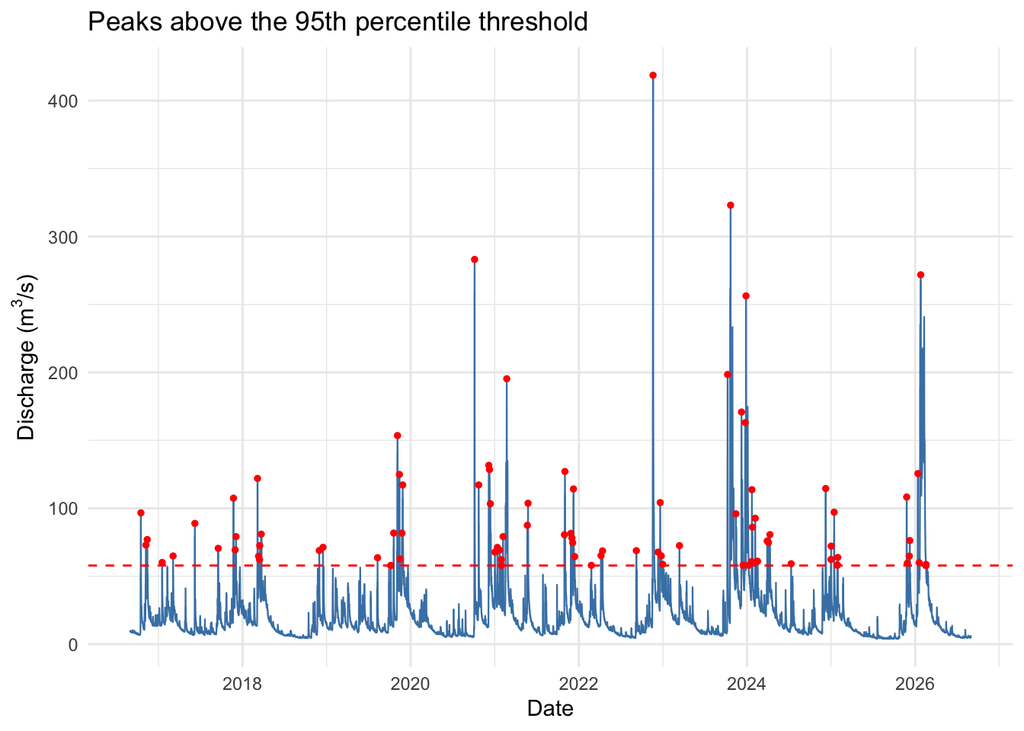

```r
# Plot
ggplot(river_data, aes(x = Timestamp, y = Discharge)) +
  geom_line(color = "steelblue", linewidth = 0.4) +
  geom_hline(yintercept = u95, linetype = "dashed", color = "red") +
  geom_point(data = peaks_95, color = "red", size = 1) +
  labs(
    title = "Peaks above the 95th percentile threshold",
    x = "Date",
    y = expression("Discharge ("*m^3*"/s)")
  ) +
  theme_minimal()
```

```r
# Count the peaks above a given percentile threshold
count_peaks <- function(p) {
  u <- quantile(river_data$Discharge, p)
  river_data %>%
    mutate(above = Discharge > u,
           start = above & !lag(above, default = FALSE)) %>%
    summarise(n = sum(start)) %>%
    pull(n)
}

# Try a range of percentiles
threshold_table <- tibble(percentile = c(0.90, 0.95, 0.96, 0.97, 0.98, 0.99, 0.995)) %>%
  mutate(
    threshold      = quantile(river_data$Discharge, percentile),
    peaks          = sapply(percentile, count_peaks),
    peaks_per_year = peaks / n_distinct(river_data$water_year)
  )

threshold_table
```

```
## # A tibble: 7 × 4
##   percentile threshold peaks peaks_per_year
##        <dbl>     <dbl> <int>          <dbl>
## 1      0.9        42.3   128          11.6
## 2      0.95       57.9    94           8.55
## 3      0.96       64.8    74           6.73
## 4      0.97       75.7    60           5.45
## 5      0.98       95.2    39           3.55
## 6      0.99      131.     22           2
## 7      0.995     166.     15           1.36
```

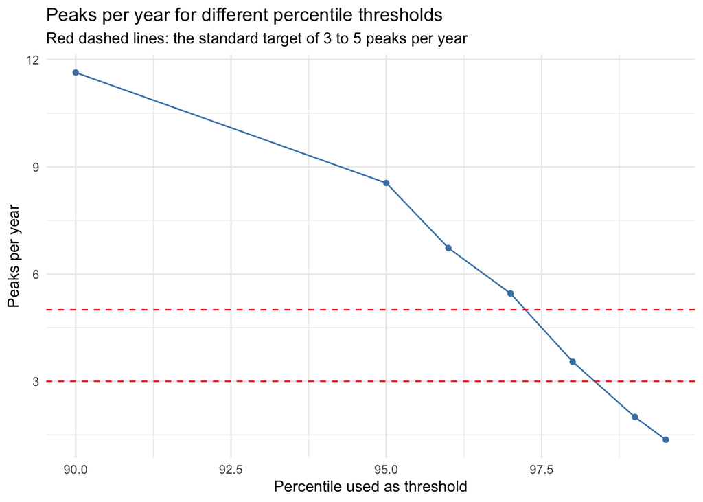

```r
# Plot
ggplot(threshold_table, aes(x = percentile * 100, y = peaks_per_year)) +
  geom_line(color = "steelblue") +
  geom_point(color = "steelblue") +
  geom_hline(yintercept = c(3, 5), linetype = "dashed", color = "red") +
  labs(
    title = "Peaks per year for different percentile thresholds",
    subtitle = "Red dashed lines: the standard target of 3 to 5 peaks per year",
    x = "Percentile used as threshold",
    y = "Peaks per year"
  ) +
  theme_minimal()
```

## mrl

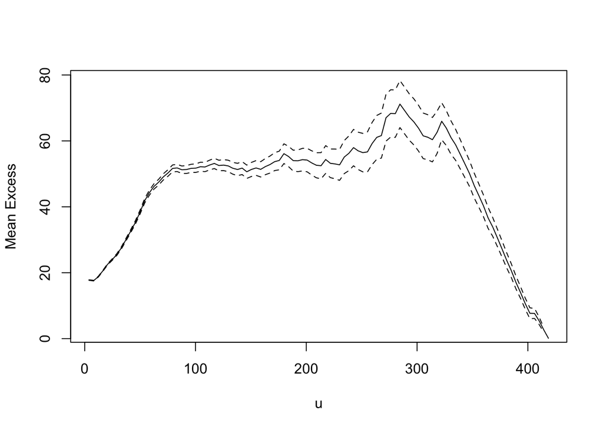

```r
library(ismev)

q <- river_data$Discharge

# Mean residual life plot: look for the lowest threshold above which the line is roughly straight
mrl.plot(q)
```

```r
# How many readings are above a candidate threshold (change 100 to the value you read off the MRL plot)
length(which(q > 80))
```

```
## [1] 9403
```

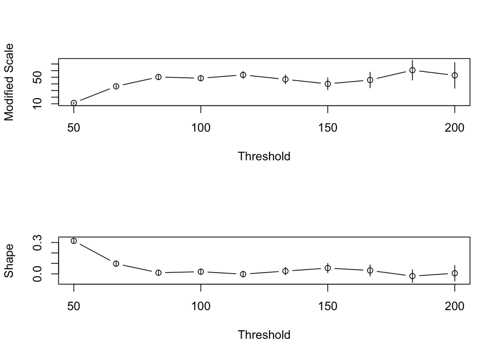

```r
# Stability of the parameter estimates across a range of thresholds
gpd.fitrange(q, 50, 200)
```

```r
# Fit the GPD at the chosen threshold and check the parameter estimates (scale, shape)
gpd_fit <- gpd.fit(q, 80, npy = 96 * 365.25)
```

```
## $threshold
## [1] 80
##
## $nexc
## [1] 9403
##
## $conv
## [1] 0
##
## $nllh
## [1] 46506.24
##
## $mle
## [1] 51.11632632  0.01186637
##
## $rate
## [1] 0.02682027
##
## $se
## [1] 0.74988069 0.01043911
```

```r
gpd_fit$mle
```

```
## [1] 51.11632632  0.01186637
```

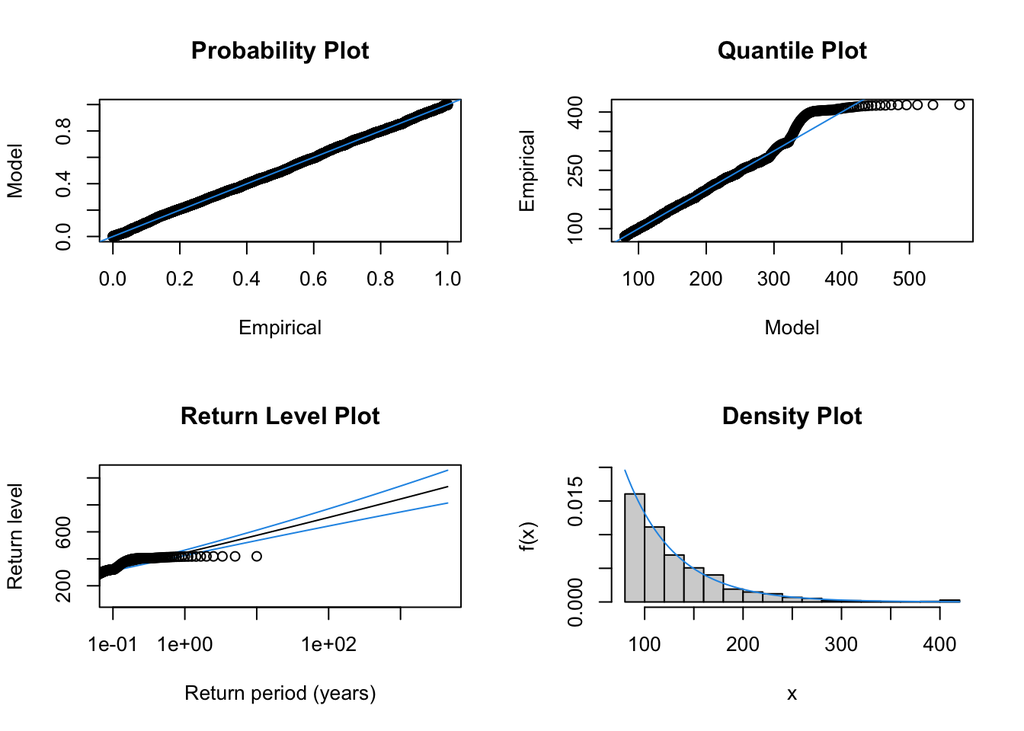

```r
# Diagnostic plots
gpd.diag(gpd_fit)
```

# Independent peaks

We apply the Robson and Reed (1999) independence rules from the lecture:

1. Two adjacent peaks must be at least three times the average time to rise apart. The time to rise is the time between a trough and its peak, averaged over at least five clean peaks above the threshold.
2. The flow at the trough between two adjacent peaks must be at least two-thirds lower than the first peak, i.e. below one third of it.

Assumptions: - a clean peak means no other candidate peak in the previous 7 days; - the trough is where the rise starts (within 5% of the week’s lowest flow).

If two peaks fail either rule, they belong to the same event and only the larger peak is kept.

```r
q <- river_data$Discharge
t <- river_data$Timestamp

independent_peaks <- function(u) {

  # Step 1: candidate peaks - the highest reading in each period above the threshold
  candidates <- river_data %>%
    mutate(row   = row_number(),
           above = Discharge > u,
           run   = cumsum(above & !lag(above, default = FALSE))) %>%
    filter(above) %>%
    group_by(run) %>%
    slice_max(Discharge, n = 1, with_ties = FALSE) %>%
    pull(row)

  # Step 2: average time to rise, calculated using at least five clean peaks exceeding the threshold
  # A clean peak has no other candidate peak in the 7 days before it
  days_since_last <- as.numeric(difftime(t[candidates], lag(t[candidates]), units = "days"))
  clean <- candidates[is.na(days_since_last) | days_since_last > 7]
  if (length(clean) < 5) stop("Fewer than five clean peaks - lower the threshold")

  # Time to rise = duration between a trough and its corresponding peak
  # Trough = last point before the peak still within 5% of the rise above the lowest flow in the previous 7 days
  rise_hours <- sapply(clean, function(p) {
    window <- which(t >= t[p] - 7 * 24 * 3600 & t <= t[p])
    low    <- min(q[window])
    trough <- max(window[q[window] <= low + 0.05 * (q[p] - low)])
    as.numeric(difftime(t[p], t[trough], units = "hours"))
  })

  min_gap_hours <- 3 * mean(rise_hours)

  # Step 3: check each pair of adjacent peaks against both rules
  kept <- candidates[1]
  for (p in candidates[-1]) {
    last   <- kept[length(kept)]                                  # the first peak of the pair
    gap    <- as.numeric(difftime(t[p], t[last], units = "hours"))
    trough <- min(q[last:p])                                      # discharge at the trough between them

    # Rule 1: at least three times the average time to rise apart
    # Rule 2: trough at least two-thirds lower than the first peak
    if (gap >= min_gap_hours & trough <= q[last] / 3) {
      kept <- c(kept, p)                 # independent: a new event
    } else if (q[p] > q[last]) {
      kept[length(kept)] <- p            # same event: keep the larger peak
    }
  }

  cat("Candidate peaks:", length(candidates), "\n")
  cat("Clean peaks used for time to rise:", length(clean), "\n")
  cat("Average time to rise (hours):", round(mean(rise_hours), 1), "\n")
  cat("Independent peaks:", length(kept), "\n")

  river_data[kept, ]
}
```

## Rechecking the threshold

Removing dependent peaks lowers the number of peaks per year, so we recheck which thresholds give 3 to 5 independent peaks per year.

```r
check <- tibble(threshold = seq(50, 200, by = 10)) %>%
  mutate(peaks_per_year = sapply(threshold, function(u) nrow(independent_peaks(u))) /
                          n_distinct(river_data$water_year))
```

```
## Candidate peaks: 128
## Clean peaks used for time to rise: 67
## Average time to rise (hours): 53.4
## Independent peaks: 60
## Candidate peaks: 84
## Clean peaks used for time to rise: 51
## Average time to rise (hours): 55.9
## Independent peaks: 46
## Candidate peaks: 61
## Clean peaks used for time to rise: 41
## Average time to rise (hours): 64.2
## Independent peaks: 39
## Candidate peaks: 47
## Clean peaks used for time to rise: 33
## Average time to rise (hours): 56.1
## Independent peaks: 33
## Candidate peaks: 43
## Clean peaks used for time to rise: 28
## Average time to rise (hours): 65.2
## Independent peaks: 27
## Candidate peaks: 38
## Clean peaks used for time to rise: 24
## Average time to rise (hours): 70.9
## Independent peaks: 23
## Candidate peaks: 37
## Clean peaks used for time to rise: 21
## Average time to rise (hours): 68.7
## Independent peaks: 19
## Candidate peaks: 24
## Clean peaks used for time to rise: 16
## Average time to rise (hours): 64.9
## Independent peaks: 14
## Candidate peaks: 19
## Clean peaks used for time to rise: 12
## Average time to rise (hours): 64.1
## Independent peaks: 10
## Candidate peaks: 22
## Clean peaks used for time to rise: 10
## Average time to rise (hours): 74.2
## Independent peaks: 9
```

[output cut: 9 more lines]

```
## Clean peaks used for time to rise: 9
## Average time to rise (hours): 69
## Independent peaks: 8
## Candidate peaks: 15
## Clean peaks used for time to rise: 8
## Average time to rise (hours): 74.5
## Independent peaks: 7
## Candidate peaks: 13
## Clean peaks used for time to rise: 8
## Average time to rise (hours): 70.6
## Independent peaks: 7
## Candidate peaks: 11
## Clean peaks used for time to rise: 6
## Average time to rise (hours): 62.5
## Independent peaks: 6
```

```r
check
```

```
## # A tibble: 16 × 2
##    threshold peaks_per_year
##        <dbl>          <dbl>
##  1        50          5.45
##  2        60          4.18
##  3        70          3.55
##  4        80          3
##  5        90          2.45
##  6       100          2.09
##  7       110          1.73
##  8       120          1.27
##  9       130          0.909
## 10       140          0.818
## 11       150          0.818
## 12       160          0.727
## 13       170          0.727
## 14       180          0.636
## 15       190          0.636
## 16       200          0.545
```

Approx 65 for threshold?

```r
u <- 65   # change to your final threshold
peaks <- independent_peaks(u)
```

```
## Candidate peaks: 71
## Clean peaks used for time to rise: 48
## Average time to rise (hours): 60.2
## Independent peaks: 44
```

```r
# Row number of each peak, and of the peak before it
peak_rows <- match(peaks$Timestamp, t)
previous  <- c(1, head(peak_rows, -1))

# Start of each rise: same definition as the trough in the time to rise,
# searching back up to 7 days but never past the previous peak
start_rows <- mapply(function(p, prev) {
  window <- which(t >= max(t[p] - 7 * 24 * 3600, t[prev]) & t <= t[p])
  low    <- min(q[window])
  max(window[q[window] <= low + 0.05 * (q[p] - low)])
}, peak_rows, previous)

# The two quantities SEPA asked for
peaks <- peaks %>%
  mutate(
    start_time     = t[start_rows],
    max_flow       = Discharge,
    time_to_peak_h = as.numeric(difftime(Timestamp, start_time, units = "hours"))
  )

peaks %>% select(start_time, Timestamp, max_flow, time_to_peak_h)
```

```
## # A tibble: 44 × 4
##    start_time          Timestamp           max_flow time_to_peak_h
##    <dttm>              <dttm>                 <dbl>          <dbl>
##  1 2016-10-14 08:15:00 2016-10-16 07:45:00     96.6           47.5
##  2 2016-11-12 03:15:00 2016-11-12 19:30:00     77.0           16.2
##  3 2017-06-06 11:15:00 2017-06-07 18:45:00     88.9           31.5
##  4 2017-09-13 22:00:00 2017-09-17 04:15:00     70.5           78.2
##  5 2017-11-20 13:45:00 2017-11-22 13:00:00    107.            47.2
##  6 2017-11-27 20:15:00 2017-12-03 13:45:00     79.2          138.
##  7 2018-03-05 09:15:00 2018-03-07 00:15:00    122.            39
##  8 2018-03-22 04:15:00 2018-03-23 06:30:00     81.0           26.2
##  9 2018-11-28 00:00:00 2018-11-30 07:00:00     68.9           55
## 10 2018-12-15 20:45:00 2018-12-16 13:15:00     71.3           16.5
## # ℹ 34 more rows
```

```r
summary(peaks$time_to_peak_h)
```

```
##    Min. 1st Qu.  Median    Mean 3rd Qu.    Max.
##    0.25   25.88   44.12   57.62   77.88  151.75
```

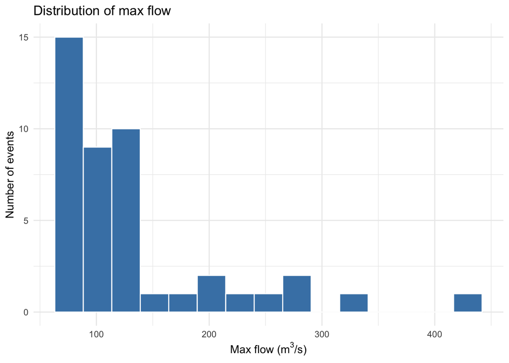

```r
# Max flow
ggplot(peaks, aes(x = max_flow)) +
  geom_histogram(bins = 15, fill = "steelblue", colour = "white") +
  labs(
    title = "Distribution of max flow",
    x = expression("Max flow ("*m^3*"/s)"),
    y = "Number of events"
  ) +
  theme_minimal()
```

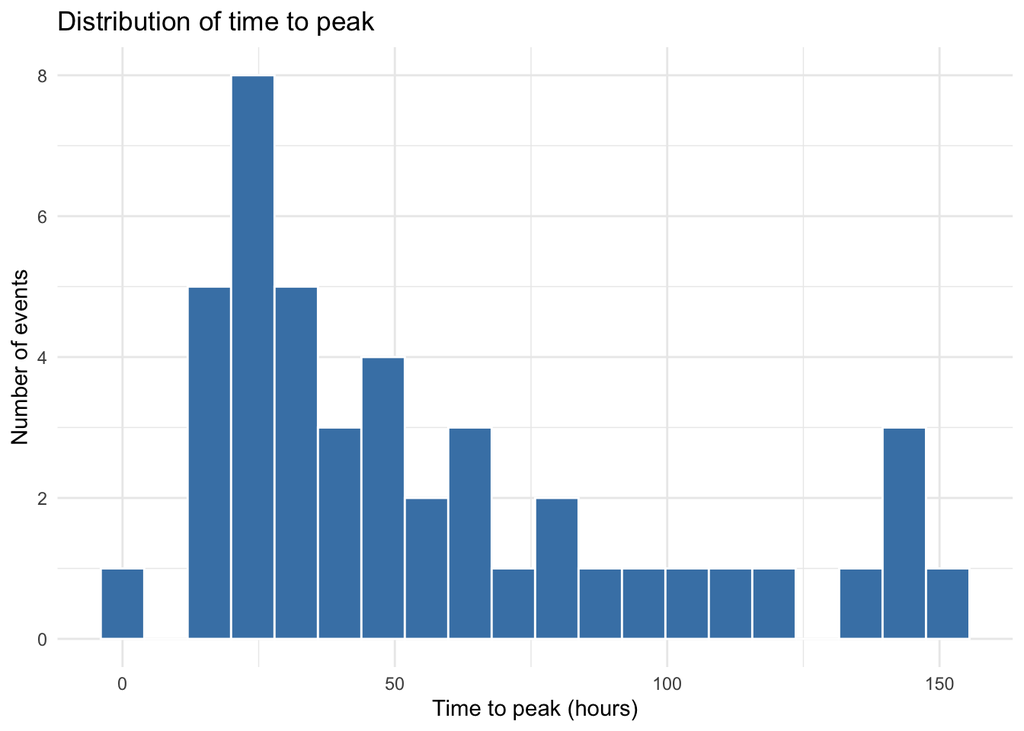

```r
# Time to peak
ggplot(peaks, aes(x = time_to_peak_h)) +
  geom_histogram(bins = 20, fill = "steelblue", colour = "white") +
  labs(
    title = "Distribution of time to peak",
    x = "Time to peak (hours)",
    y = "Number of events"
  ) +
  theme_minimal()
```

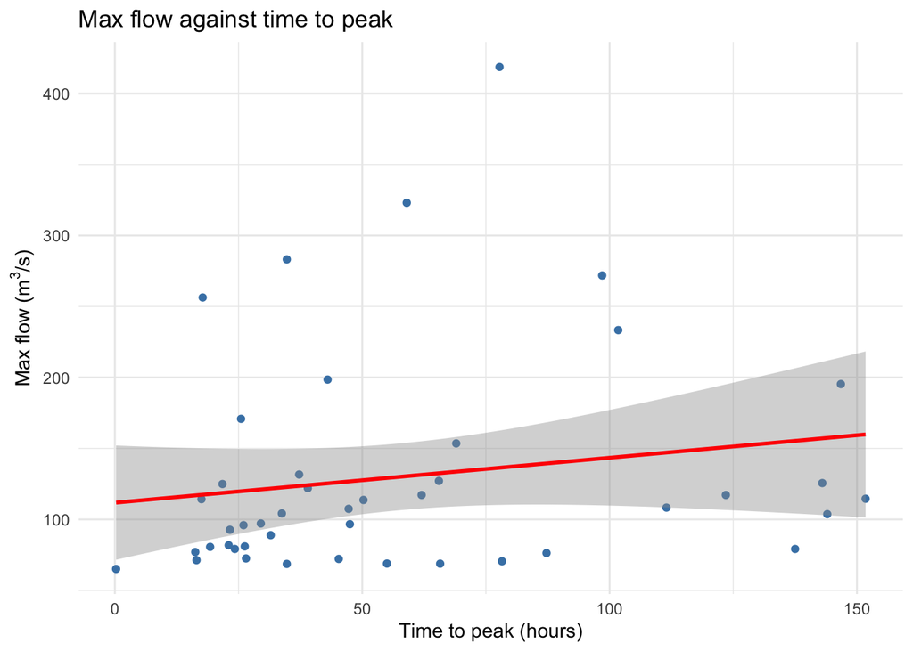

```r
ggplot(peaks, aes(x = time_to_peak_h, y = max_flow)) +
  geom_point(color = "steelblue") +
  geom_smooth(method = "lm", color = "red") +
  labs(
    title = "Max flow against time to peak",
    x = "Time to peak (hours)",
    y = expression("Max flow ("*m^3*"/s)")
  ) +
  theme_minimal()
```

```r
cor.test(peaks$time_to_peak_h, peaks$max_flow, method = "spearman", exact = FALSE)
```

```
##
##  Spearman's rank correlation rho
##
## data:  peaks$time_to_peak_h and peaks$max_flow
## S = 10112, p-value = 0.05852
## alternative hypothesis: true rho is not equal to 0
## sample estimates:
##       rho
## 0.2874159
```

Weak positive relationship.

```r
# Number of events and typical values in each season
peaks %>%
  group_by(season) %>%
  summarise(
    Events = n(),
    `Median max flow` = median(max_flow),
    `Median time to peak (h)` = median(time_to_peak_h)
  )
```

```
## # A tibble: 4 × 4
##   season Events `Median max flow` `Median time to peak (h)`
##   <fct>   <int>             <dbl>                     <dbl>
## 1 Winter     18             109.                       35.5
## 2 Spring      6              80.8                      30.6
## 3 Summer      1              88.9                      31.5
## 4 Autumn     19             117.                       59
```

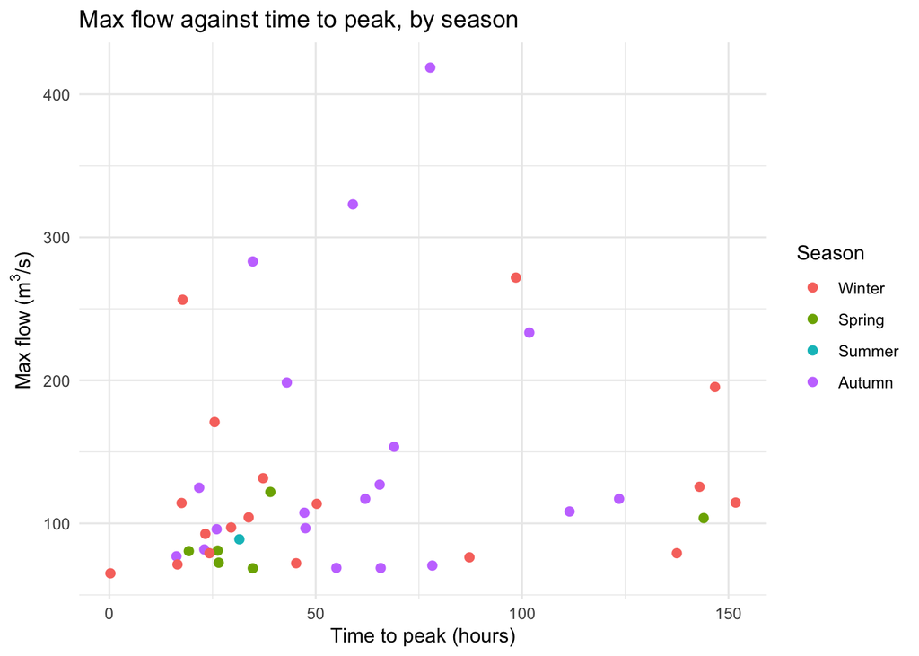

```r
# Relationship, coloured by season
ggplot(peaks, aes(x = time_to_peak_h, y = max_flow, color = season)) +
  geom_point(size = 2) +
  labs(
    title = "Max flow against time to peak, by season",
    x = "Time to peak (hours)",
    y = expression("Max flow ("*m^3*"/s)"),
    color = "Season"
  ) +
  theme_minimal()
```

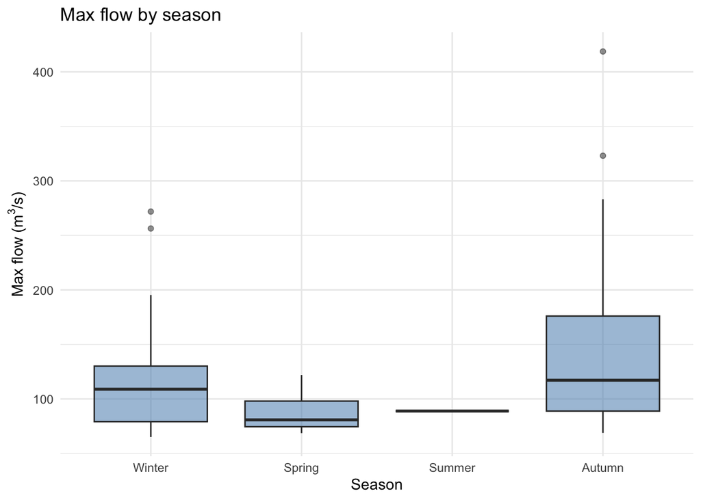

```r
# Max flow by season
ggplot(peaks, aes(x = season, y = max_flow)) +
  geom_boxplot(fill = "steelblue", alpha = 0.5) +
  labs(
    title = "Max flow by season",
    x = "Season",
    y = expression("Max flow ("*m^3*"/s)")
  ) +
  theme_minimal()
```

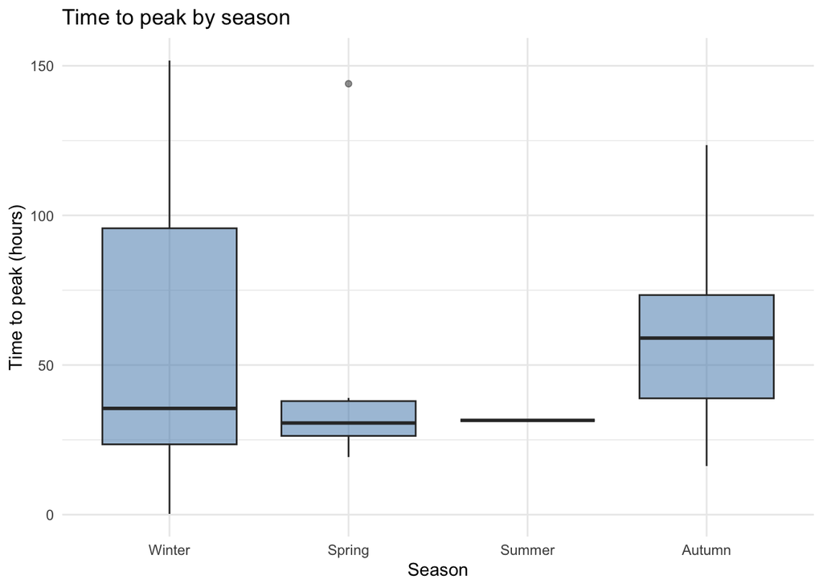

```r
# Time to peak by season
ggplot(peaks, aes(x = season, y = time_to_peak_h)) +
  geom_boxplot(fill = "steelblue", alpha = 0.5) +
  labs(
    title = "Time to peak by season",
    x = "Season",
    y = "Time to peak (hours)"
  ) +
  theme_minimal()
```

```r
results <- tibble()

for (u in c(55, 60, 65, 70, 75)) {
  peaks <- independent_peaks(u)

  # Start of each rise and time to peak (same code as before)
  peak_rows <- match(peaks$Timestamp, t)
  previous  <- c(1, head(peak_rows, -1))
  start_rows <- mapply(function(p, prev) {
    window <- which(t >= max(t[p] - 7 * 24 * 3600, t[prev]) & t <= t[p])
    low    <- min(q[window])
    max(window[q[window] <= low + 0.05 * (q[p] - low)])
  }, peak_rows, previous)
  time_to_peak_h <- as.numeric(difftime(peaks$Timestamp, t[start_rows], units = "hours"))

  # One row of results for this threshold
  results <- bind_rows(results, tibble(
    threshold             = u,
    events                = nrow(peaks),
    events_per_year       = nrow(peaks) / n_distinct(river_data$water_year),
    median_max_flow       = median(peaks$Discharge),
    median_time_to_peak_h = median(time_to_peak_h),
    spearman_rho          = cor(peaks$Discharge, time_to_peak_h, method = "spearman")
  ))
}
```

```
## Candidate peaks: 102
## Clean peaks used for time to rise: 60
## Average time to rise (hours): 57.8
## Independent peaks: 57
## Candidate peaks: 84
## Clean peaks used for time to rise: 51
## Average time to rise (hours): 55.9
## Independent peaks: 46
## Candidate peaks: 71
## Clean peaks used for time to rise: 48
## Average time to rise (hours): 60.2
## Independent peaks: 44
## Candidate peaks: 61
## Clean peaks used for time to rise: 41
## Average time to rise (hours): 64.2
## Independent peaks: 39
## Candidate peaks: 52
## Clean peaks used for time to rise: 37
## Average time to rise (hours): 60.1
## Independent peaks: 37
```

```r
results
```

```
## # A tibble: 5 × 6
##   threshold events events_per_year median_max_flow median_time_to_peak_h
##       <dbl>  <int>           <dbl>           <dbl>                 <dbl>
## 1        55     57            5.18            81.8                  43
## 2        60     46            4.18           100.                   44.1
## 3        65     44            4              106.                   44.1
## 4        70     39            3.55           108.                   43
## 5        75     37            3.36           114.                   47.2
## # ℹ 1 more variable: spearman_rho <dbl>
```

# NOTES

- Remove 100 and below for quality?
- Change start date to 1 day later?
- “Water year”?